# regression_sector_specific

# Employment to population ratio

## Crop sector

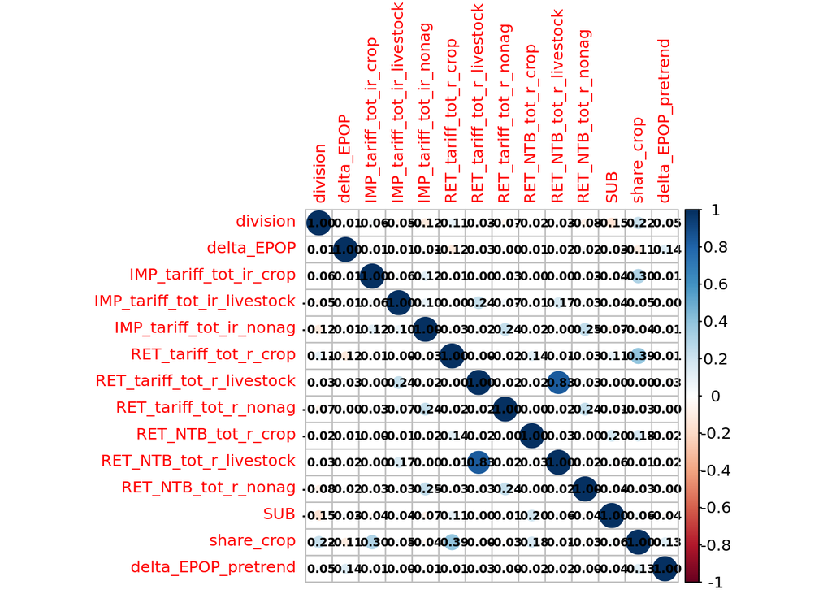

[output not shown]

models[[1]]

models[[2]]

models[[3]]

models[[4]]

Dependent Var.:

delta_EPOP

delta_EPOP

delta_EPOP

delta_EPOP

IMP_tariff_tot_ir_crop

0.0016 (0.0012)

0.0041*** (0.0007)

0.0041*** (0.0007)

0.0041*** (0.0007)

IMP_tariff_tot_ir_livestock

-0.0011 (0.0009)

0.0001 (0.0009)

0.0002 (0.0009)

0.0002 (0.0009)

IMP_tariff_tot_ir_nonag

-5.47e-5 (0.0002)

-7.52e-5 (0.0002)

-0.0001 (0.0002)

-0.0001 (0.0002)

RET_tariff_tot_r_crop

-0.0052** (0.0017)

-0.0013 (0.0010)

-0.0014 (0.0010)

-0.0014 (0.0010)

RET_tariff_tot_r_livestock

0.0012 (0.0015)

0.0009 (0.0015)

0.0009 (0.0015)

0.0009 (0.0015)

RET_tariff_tot_r_nonag

-0.0006 (0.0007)

-0.0008 (0.0007)

-0.0007 (0.0007)

-0.0007 (0.0007)

RET_NTB_tot_r_crop

5.23e-5 (0.0004)

0.0007* (0.0003)

0.0006* (0.0003)

0.0006* (0.0003)

RET_NTB_tot_r_livestock

-0.0007 (0.0048)

-0.0002 (0.0048)

-0.0002 (0.0049)

-0.0002 (0.0049)

RET_NTB_tot_r_nonag

0.0016. (0.0009)

0.0016. (0.0009)

0.0014 (0.0009)

0.0014 (0.0009)

SUB

1.84e-7. (9.99e-8)

1.42e-7 (9.68e-8)

2.02e-7* (1.01e-7)

2.04e-7* (9.98e-8)

as.factor(year)2018 x share_crop

-0.0058* (0.0025)

-0.0060* (0.0025)

-0.0061* (0.0027)

as.factor(year)2019 x share_crop

-0.0202*** (0.0043)

-0.0204*** (0.0044)

-0.0205*** (0.0043)

year x delta_EPOP_pretrend

4.43e-6 (2.84e-5)

Fixed-Effects:

——————

——————-

——————-

——————-

Year FE

Yes

Yes

Yes

Yes

Sector x year-month FE

No

Yes

Yes

Yes

Census division x year-month FE

No

No

Yes

Yes

Pre-trend CZ outcome 2017

No

No

No

Yes

year

Yes

Yes

Yes

Yes

________________________________

__________________

___________________

___________________

___________________

S.E.: Clustered

by: fips

by: fips

by: fips

by: fips

Observations

4,394

4,394

4,394

4,394

R2

0.03424

0.10677

0.11147

0.11152

Adj. R2

0.03181

0.10412

0.10556

0.10541

F-test

7.0768

20.192

9.4999

9.1882

F-test, p-value

6.52e-12

1.27e-45

3.52e-39

9.82e-39

RMSE

0.00089

0.00085

0.00085

0.00085

models[[1]]

models[[2]]

models[[3]]

models[[4]]

Dependent Var.:

delta_EPOP

delta_EPOP

delta_EPOP

delta_EPOP

IMP_tariff_tot_ir_crop

0.0017 (0.0011)

0.0041*** (0.0007)

0.0041*** (0.0007)

0.0041*** (0.0007)

IMP_tariff_tot_ir_livestock

-0.0013 (0.0009)

-0.0002 (0.0009)

-0.0002 (0.0009)

-0.0002 (0.0009)

IMP_tariff_tot_ir_nonag

2.36e-6 (0.0002)

-3.48e-5 (0.0002)

-7.13e-5 (0.0002)

-7.07e-5 (0.0002)

RET_tariff_tot_r_crop

-0.0043** (0.0015)

-0.0012 (0.0010)

-0.0013 (0.0010)

-0.0013 (0.0010)

RET_tariff_tot_r_livestock

0.0001 (0.0013)

-0.0006 (0.0013)

-0.0009 (0.0013)

-0.0009 (0.0013)

RET_tariff_tot_r_nonag

-0.0003 (0.0004)

-0.0004 (0.0004)

-0.0004 (0.0004)

-0.0004 (0.0004)

RET_NTB_tot_IV_r_crop

-0.0036* (0.0015)

0.0006 (0.0010)

0.0006 (0.0010)

0.0006 (0.0010)

RET_NTB_tot_IV_r_livestock

0.0029 (0.0027)

0.0039 (0.0027)

0.0046. (0.0027)

0.0046. (0.0027)

RET_NTB_tot_IV_r_nonag

0.0007 (0.0006)

0.0006 (0.0006)

0.0005 (0.0006)

0.0005 (0.0006)

SUB

2.93e-7* (1.15e-7)

1.37e-7 (1.01e-7)

1.97e-7. (1.04e-7)

1.99e-7. (1.04e-7)

as.factor(year)2018 x share_crop

-0.0059* (0.0026)

-0.0061* (0.0027)

-0.0062* (0.0028)

as.factor(year)2019 x share_crop

-0.0204*** (0.0046)

-0.0206*** (0.0046)

-0.0207*** (0.0046)

year x delta_EPOP_pretrend

3.63e-6 (2.84e-5)

Fixed-Effects:

——————

——————-

——————-

——————-

Year FE

Yes

Yes

Yes

Yes

Sector x year-month FE

No

Yes

Yes

Yes

Census division x year-month FE

No

No

Yes

Yes

Pre-trend CZ outcome 2017

No

No

No

Yes

year

Yes

Yes

Yes

Yes

________________________________

__________________

___________________

___________________

___________________

S.E.: Clustered

by: fips

by: fips

by: fips

by: fips

Observations

4,394

4,394

4,394

4,394

R2

0.03775

0.10350

0.10935

0.10939

Adj. R2

0.03534

0.10084

0.10343

0.10326

F-test

7.8325

19.502

9.2971

8.9905

F-test, p-value

1.82e-13

5.93e-44

3.72e-38

1.05e-37

RMSE

0.00089

0.00086

0.00085

0.00085

## Livestock sector

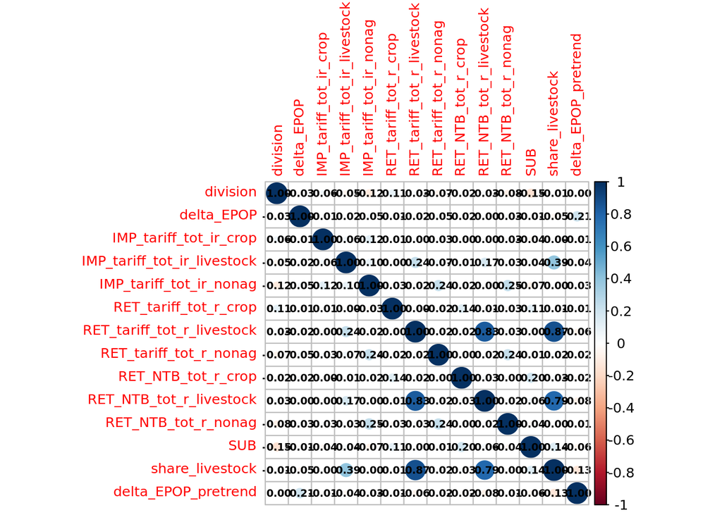

[output not shown]

models[[1]]

models[[2]]

models[[3]]

models[[4]]

Dependent Var.:

delta_EPOP

delta_EPOP

delta_EPOP

delta_EPOP

IMP_tariff_tot_ir_crop

-0.0003 (0.0002)

-0.0003 (0.0002)

-0.0003 (0.0002)

-0.0002 (0.0002)

IMP_tariff_tot_ir_livestock

0.0049* (0.0022)

0.0062 (0.0044)

0.0062 (0.0044)

0.0061 (0.0044)

IMP_tariff_tot_ir_nonag

0.0004. (0.0002)

0.0005. (0.0003)

0.0004 (0.0003)

0.0004 (0.0003)

RET_tariff_tot_r_crop

0.0004 (0.0006)

0.0005 (0.0006)

0.0006 (0.0007)

0.0005 (0.0006)

RET_tariff_tot_r_livestock

-0.0056 (0.0045)

-0.0022 (0.0136)

-0.0022 (0.0137)

-0.0038 (0.0139)

RET_tariff_tot_r_nonag

0.0025* (0.0011)

0.0025* (0.0011)

0.0024* (0.0011)

0.0021* (0.0010)

RET_NTB_tot_r_crop

0.0004 (0.0005)

0.0004 (0.0005)

0.0004 (0.0005)

0.0005 (0.0005)

RET_NTB_tot_r_livestock

0.0221* (0.0104)

0.0252. (0.0153)

0.0261. (0.0158)

0.0262 (0.0160)

RET_NTB_tot_r_nonag

-0.0003 (0.0005)

-0.0003 (0.0005)

-0.0002 (0.0005)

-7.53e-5 (0.0005)

SUB

-1.99e-7 (3e-7)

-1.41e-7 (3.6e-7)

-1.8e-7 (3.8e-7)

-1.35e-7 (3.84e-7)

as.factor(year)2018 x share_livestock

-0.0030 (0.0156)

-0.0033 (0.0158)

-0.0008 (0.0160)

as.factor(year)2019 x share_livestock

-0.0072 (0.0232)

-0.0076 (0.0237)

-0.0049 (0.0240)

year x delta_EPOP_pretrend

8.56e-5* (3.59e-5)

Fixed-Effects:

—————-

—————–

—————-

——————

Year FE

Yes

Yes

Yes

Yes

Sector x year-month FE

No

Yes

Yes

Yes

Census division x year-month FE

No

No

Yes

Yes

Pre-trend CZ outcome 2017

No

No

No

Yes

year

Yes

Yes

Yes

Yes

_____________________________________

________________

_________________

________________

__________________

S.E.: Clustered

by: fips

by: fips

by: fips

by: fips

Observations

4,394

4,394

4,394

4,394

R2

0.01258

0.01365

0.01452

0.03453

Adj. R2

0.01010

0.01072

0.00797

0.02789

F-test

2.5435

2.3370

1.1159

2.6181

F-test, p-value

0.00340

0.00434

0.30586

4.26e-6

RMSE

0.00151

0.00151

0.00151

0.00149

models[[1]]

models[[2]]

models[[3]]

models[[4]]

Dependent Var.:

delta_EPOP

delta_EPOP

delta_EPOP

delta_EPOP

IMP_tariff_tot_ir_crop

-0.0004 (0.0002)

-0.0004 (0.0002)

-0.0003 (0.0002)

-0.0003 (0.0002)

IMP_tariff_tot_ir_livestock

0.0043* (0.0020)

0.0073 (0.0055)

0.0073 (0.0056)

0.0073 (0.0056)

IMP_tariff_tot_ir_nonag

0.0004. (0.0003)

0.0004. (0.0002)

0.0004 (0.0002)

0.0003 (0.0002)

RET_tariff_tot_r_crop

0.0004 (0.0006)

0.0005 (0.0006)

0.0005 (0.0006)

0.0004 (0.0006)

RET_tariff_tot_r_livestock

-0.0020 (0.0054)

0.0067 (0.0168)

0.0067 (0.0169)

0.0052 (0.0171)

RET_tariff_tot_r_nonag

0.0028* (0.0012)

0.0028* (0.0012)

0.0027* (0.0012)

0.0024* (0.0011)

RET_NTB_tot_IV_r_crop

0.0005 (0.0009)

0.0008 (0.0010)

0.0008 (0.0010)

0.0010 (0.0010)

RET_NTB_tot_IV_r_livestock

0.0075 (0.0108)

0.0221 (0.0265)

0.0218 (0.0266)

0.0226 (0.0268)

RET_NTB_tot_IV_r_nonag

-0.0005 (0.0004)

-0.0005 (0.0004)

-0.0005 (0.0004)

-0.0004 (0.0004)

SUB

-1.9e-7 (2.82e-7)

-8.95e-8 (3.52e-7)

-1.23e-7 (3.81e-7)

-7.35e-8 (3.84e-7)

as.factor(year)2018 x share_livestock

-0.0110 (0.0220)

-0.0111 (0.0221)

-0.0089 (0.0223)

as.factor(year)2019 x share_livestock

-0.0223 (0.0372)

-0.0222 (0.0375)

-0.0201 (0.0377)

year x delta_EPOP_pretrend

8.62e-5* (3.59e-5)

Fixed-Effects:

—————–

——————

——————

——————

Year FE

Yes

Yes

Yes

Yes

Sector x year-month FE

No

Yes

Yes

Yes

Census division x year-month FE

No

No

Yes

Yes

Pre-trend CZ outcome 2017

No

No

No

Yes

year

Yes

Yes

Yes

Yes

_____________________________________

_________________

__________________

__________________

__________________

S.E.: Clustered

by: fips

by: fips

by: fips

by: fips

Observations

4,394

4,394

4,394

4,394

R2

0.01158

0.01630

0.01681

0.03713

Adj. R2

0.00910

0.01338

0.01027

0.03051

F-test

2.3382

2.7995

1.2943

2.8225

F-test, p-value

0.00738

0.00056

0.13518

5.9e-7

RMSE

0.00151

0.00150

0.00150

0.00149

## non ag

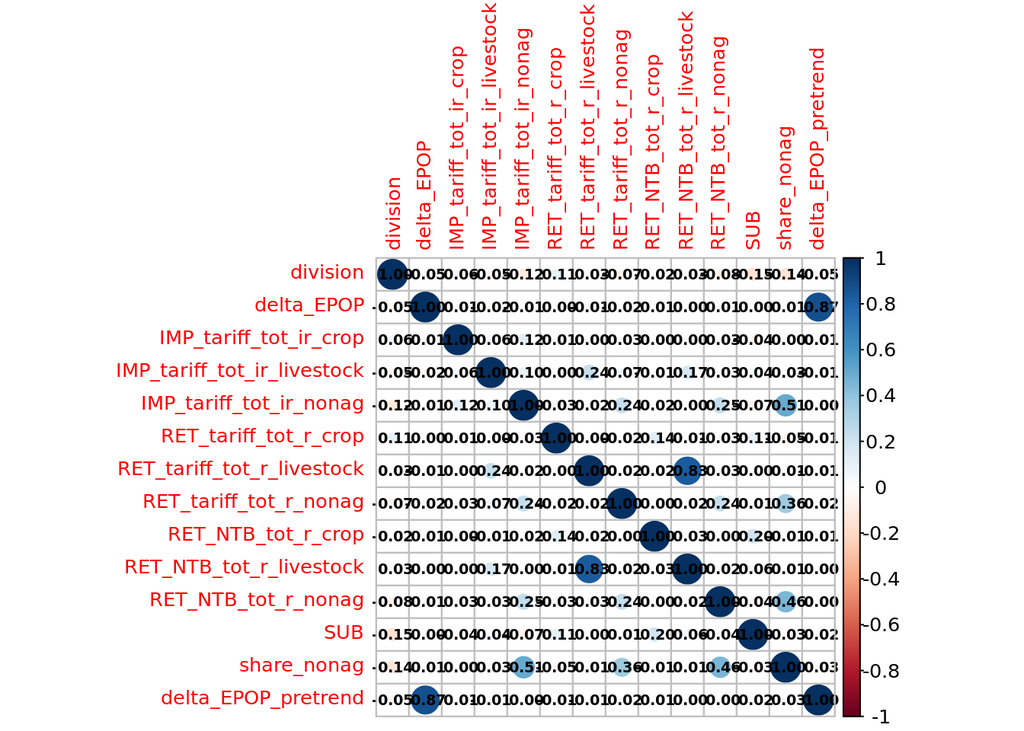

[output not shown]

models[[1]]

models[[2]]

models[[3]]

models[[4]]

Dependent Var.:

delta_EPOP

delta_EPOP

delta_EPOP

delta_EPOP

IMP_tariff_tot_ir_crop

-0.0003 (0.0004)

-7.17e-5 (0.0004)

-0.0005 (0.0005)

-0.0010 (0.0007)

IMP_tariff_tot_ir_livestock

-0.0033 (0.0032)

-0.0035 (0.0033)

-0.0039 (0.0032)

-0.0047 (0.0031)

IMP_tariff_tot_ir_nonag

-0.0010 (0.0009)

-0.0033* (0.0014)

-0.0032* (0.0013)

-0.0025 (0.0016)

RET_tariff_tot_r_crop

-0.0006 (0.0007)

-0.0004 (0.0007)

-0.0005 (0.0008)

-0.0006 (0.0011)

RET_tariff_tot_r_livestock

-0.0089 (0.0055)

-0.0088 (0.0055)

-0.0085 (0.0055)

-0.0070 (0.0065)

RET_tariff_tot_r_nonag

-0.0010 (0.0062)

-0.0067 (0.0060)

-0.0067 (0.0059)

0.0212 (0.0217)

RET_NTB_tot_r_crop

0.0001 (0.0014)

3.31e-5 (0.0014)

0.0002 (0.0014)

0.0002 (0.0016)

RET_NTB_tot_r_livestock

0.0236 (0.0162)

0.0213 (0.0161)

0.0206 (0.0163)

0.0298 (0.0189)

RET_NTB_tot_r_nonag

0.0080 (0.0054)

0.0037 (0.0057)

0.0037 (0.0054)

0.0061 (0.0070)

SUB

-7.32e-8 (4.74e-7)

-2.73e-7 (4.77e-7)

-5.51e-7 (4.84e-7)

-1.01e-6* (5.12e-7)

as.factor(year)2018 x share_nonag

0.0080* (0.0035)

0.0080* (0.0036)

0.0007 (0.0058)

as.factor(year)2019 x share_nonag

0.0114* (0.0054)

0.0113* (0.0057)

0.0002 (0.0088)

year x delta_EPOP_pretrend

0.0004* (0.0002)

Fixed-Effects:

——————

——————

——————

——————-

Year FE

Yes

Yes

Yes

Yes

Sector x year-month FE

No

Yes

Yes

Yes

Census division x year-month FE

No

No

Yes

Yes

Pre-trend CZ outcome 2017

No

No

No

Yes

year

Yes

Yes

Yes

Yes

_________________________________

__________________

__________________

__________________

___________________

S.E.: Clustered

by: fips

by: fips

by: fips

by: fips

Observations

4,394

4,394

4,394

4,394

R2

0.00705

0.01080

0.01385

0.36709

Adj. R2

0.00456

0.00786

0.00730

0.36274

F-test

1.4179

1.8439

1.0639

42.457

F-test, p-value

0.15773

0.03206

0.37365

2.86e-193

RMSE

0.00462

0.00461

0.00460

0.00369

models[[1]]

models[[2]]

models[[3]]

models[[4]]

Dependent Var.:

delta_EPOP

delta_EPOP

delta_EPOP

delta_EPOP

IMP_tariff_tot_ir_crop

-0.0003 (0.0004)

-0.0003 (0.0004)

-0.0005 (0.0005)

-0.0009 (0.0006)

IMP_tariff_tot_ir_livestock

-0.0032 (0.0033)

-0.0032 (0.0033)

-0.0034 (0.0033)

-0.0045 (0.0032)

IMP_tariff_tot_ir_nonag

-0.0018* (0.0009)

-0.0025* (0.0013)

-0.0025. (0.0013)

-0.0019 (0.0015)

RET_tariff_tot_r_crop

-0.0004 (0.0007)

-0.0003 (0.0007)

-0.0003 (0.0008)

-6.79e-5 (0.0010)

RET_tariff_tot_r_livestock

-0.0006 (0.0042)

-0.0010 (0.0042)

0.0002 (0.0043)

0.0037 (0.0049)

RET_tariff_tot_r_nonag

-0.0062. (0.0034)

-0.0088* (0.0042)

-0.0087* (0.0043)

0.0193 (0.0225)

RET_NTB_tot_IV_r_crop

0.0011 (0.0027)

0.0011 (0.0027)

0.0010 (0.0027)

-0.0002 (0.0031)

RET_NTB_tot_IV_r_livestock

-0.0023 (0.0102)

-0.0026 (0.0102)

-0.0063 (0.0103)

-0.0043 (0.0096)

RET_NTB_tot_IV_r_nonag

0.0130** (0.0044)

0.0113* (0.0057)

0.0114* (0.0054)

0.0115 (0.0077)

SUB

2e-8 (4.59e-7)

-1.41e-7 (4.66e-7)

-4.19e-7 (4.82e-7)

-8.25e-7. (4.98e-7)

as.factor(year)2018 x share_nonag

0.0058. (0.0035)

0.0058 (0.0035)

-0.0004 (0.0054)

as.factor(year)2019 x share_nonag

0.0034 (0.0068)

0.0035 (0.0069)

-0.0062 (0.0096)

year x delta_EPOP_pretrend

0.0004* (0.0002)

Fixed-Effects:

—————–

——————

——————

——————-

Year FE

Yes

Yes

Yes

Yes

Sector x year-month FE

No

Yes

Yes

Yes

Census division x year-month FE

No

No

Yes

Yes

Pre-trend CZ outcome 2017

No

No

No

Yes

year

Yes

Yes

Yes

Yes

_________________________________

_________________

__________________

__________________

___________________

S.E.: Clustered

by: fips

by: fips

by: fips

by: fips

Observations

4,394

4,394

4,394

4,394

R2

0.01573

0.01713

0.02013

0.37209

Adj. R2

0.01326

0.01422

0.01362

0.36777

F-test

3.1901

2.9445

1.5558

43.377

F-test, p-value

0.00026

0.00028

0.02985

5.78e-197

RMSE

0.00460

0.00459

0.00459

0.00367

# Log employment change

## Crop sector

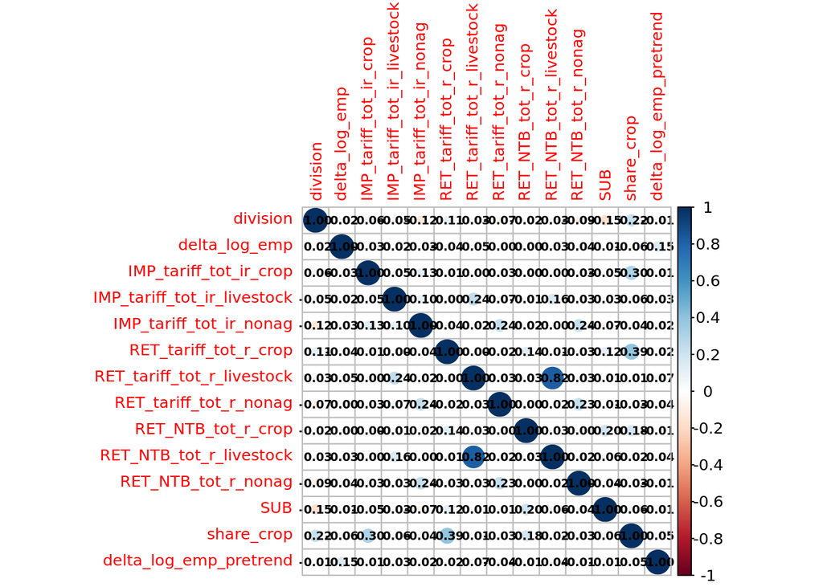

```
## NOTES: 2 observation removed because of 0-weight.
##        1,959 observations removed because of NA values (LHS: 618, RHS: 1,886).
## NOTES: 2 observation removed because of 0-weight.
##        1,959 observations removed because of NA values (LHS: 618, RHS: 1,886).
## NOTES: 2 observation removed because of 0-weight.
##        1,959 observations removed because of NA values (LHS: 618, RHS: 1,886).
```

```
## NOTES: 2 observation removed because of 0-weight.
##        1,966 observations removed because of NA values (LHS: 618, RHS: 1,950).
```

```
## NOTES: 2 observation removed because of 0-weight.
##        1,959 observations removed because of NA values (LHS: 618, RHS: 1,886).
## NOTES: 2 observation removed because of 0-weight.
##        1,959 observations removed because of NA values (LHS: 618, RHS: 1,886).
## NOTES: 2 observation removed because of 0-weight.
##        1,959 observations removed because of NA values (LHS: 618, RHS: 1,886).
```

```
## NOTES: 2 observation removed because of 0-weight.
##        1,966 observations removed because of NA values (LHS: 618, RHS: 1,950).
```

models[[1]]

models[[2]]

models[[3]]

models[[4]]

Dependent Var.:

delta_log_emp

delta_log_emp

delta_log_emp

delta_log_emp

IMP_tariff_tot_ir_crop

-0.1074 (0.0821)

0.0586 (0.0450)

0.0642 (0.0414)

0.0693 (0.0422)

IMP_tariff_tot_ir_livestock

-0.0840 (0.1860)

0.0019 (0.1855)

0.0437 (0.1946)

0.0387 (0.1913)

IMP_tariff_tot_ir_nonag

-0.0174 (0.0643)

-0.0188 (0.0645)

-0.0323 (0.0632)

-0.0327 (0.0622)

RET_tariff_tot_r_crop

-0.3206*** (0.0863)

-0.0291 (0.0605)

-0.0922 (0.0680)

-0.0907 (0.0686)

RET_tariff_tot_r_livestock

0.8721* (0.4179)

0.8476* (0.4146)

0.7922. (0.4244)

0.7208. (0.4114)

RET_tariff_tot_r_nonag

-0.2725 (0.2957)

-0.2812 (0.2956)

-0.2436 (0.2793)

-0.2388 (0.2691)

RET_NTB_tot_r_crop

-0.0392 (0.0473)

0.0042 (0.0434)

-0.0188 (0.0480)

-0.0250 (0.0467)

RET_NTB_tot_r_livestock

-0.9449 (1.043)

-0.8922 (1.035)

-1.001 (1.070)

-0.9177 (1.083)

RET_NTB_tot_r_nonag

0.3989. (0.2048)

0.3985. (0.2050)

0.3613. (0.1943)

0.3977. (0.2095)

SUB

-1.15e-5 (2.25e-5)

-1.37e-5 (2.25e-5)

1.41e-5 (2.4e-5)

1.61e-5 (2.39e-5)

as.factor(year)2018 x share_crop

-0.6316*** (0.1582)

-0.5688** (0.1789)

-0.6259*** (0.1810)

as.factor(year)2019 x share_crop

-1.312*** (0.2553)

-1.265*** (0.2646)

-1.328*** (0.2672)

year x delta_log_emp_pretrend

4.74e-5** (1.79e-5)

Fixed-Effects:

——————-

——————-

——————

——————-

Year FE

Yes

Yes

Yes

Yes

Sector x year-month FE

No

Yes

Yes

Yes

Census division x year-month FE

No

No

Yes

Yes

Pre-trend CZ outcome 2017

No

No

No

Yes

year

Yes

Yes

Yes

Yes

________________________________

___________________

___________________

__________________

___________________

S.E.: Clustered

by: fips

by: fips

by: fips

by: fips

Observations

4,321

4,321

4,321

4,314

R2

0.01049

0.01519

0.02439

0.03497

Adj. R2

0.00797

0.01222

0.01780

0.02821

F-test

2.0840

2.5658

1.8639

2.6069

F-test, p-value

0.01855

0.00160

0.00348

4.77e-6

RMSE

0.24517

0.24458

0.24344

0.24209

models[[1]]

models[[2]]

models[[3]]

models[[4]]

Dependent Var.:

delta_log_emp

delta_log_emp

delta_log_emp

delta_log_emp

IMP_tariff_tot_ir_crop

-0.0914 (0.0757)

0.0579 (0.0439)

0.0629 (0.0413)

0.0677 (0.0421)

IMP_tariff_tot_ir_livestock

-0.0604 (0.1910)

0.0168 (0.1908)

0.0440 (0.1998)

0.0352 (0.1965)

IMP_tariff_tot_ir_nonag

0.0033 (0.0640)

0.0006 (0.0641)

-0.0164 (0.0637)

-0.0156 (0.0632)

RET_tariff_tot_r_crop

-0.2672*** (0.0753)

-0.0389 (0.0592)

-0.0998 (0.0673)

-0.0981 (0.0680)

RET_tariff_tot_r_livestock

0.7543. (0.4002)

0.7081. (0.3944)

0.5306 (0.4040)

0.4683 (0.3842)

RET_tariff_tot_r_nonag

-0.1250 (0.2033)

-0.1253 (0.1997)

-0.1186 (0.2001)

-0.1015 (0.1790)

RET_NTB_tot_IV_r_crop

-0.2921** (0.1110)

0.0100 (0.0894)

-0.0287 (0.0947)

-0.0454 (0.0939)

RET_NTB_tot_IV_r_livestock

-0.3657 (0.5822)

-0.3074 (0.5797)

-0.0551 (0.5767)

-0.0082 (0.5779)

RET_NTB_tot_IV_r_nonag

0.0915 (0.1677)

0.0869 (0.1683)

0.0880 (0.1597)

0.0968 (0.1716)

SUB

-9.46e-7 (2.15e-5)

-1.13e-5 (2.16e-5)

1.38e-5 (2.35e-5)

1.59e-5 (2.34e-5)

as.factor(year)2018 x share_crop

-0.6529*** (0.1660)

-0.5929** (0.1875)

-0.6460*** (0.1883)

as.factor(year)2019 x share_crop

-1.300*** (0.2683)

-1.261*** (0.2785)

-1.316*** (0.2793)

year x delta_log_emp_pretrend

4.6e-5* (1.82e-5)

Fixed-Effects:

——————-

——————-

——————

——————-

Year FE

Yes

Yes

Yes

Yes

Sector x year-month FE

No

Yes

Yes

Yes

Census division x year-month FE

No

No

Yes

Yes

Pre-trend CZ outcome 2017

No

No

No

Yes

year

Yes

Yes

Yes

Yes

________________________________

___________________

___________________

__________________

___________________

S.E.: Clustered

by: fips

by: fips

by: fips

by: fips

Observations

4,321

4,321

4,321

4,314

R2

0.00741

0.01156

0.02142

0.03144

Adj. R2

0.00487

0.00857

0.01480

0.02466

F-test

1.4664

1.9446

1.6316

2.3353

F-test, p-value

0.13731

0.02175

0.01820

5.86e-5

RMSE

0.24555

0.24503

0.24381

0.24253

## Livestock sector

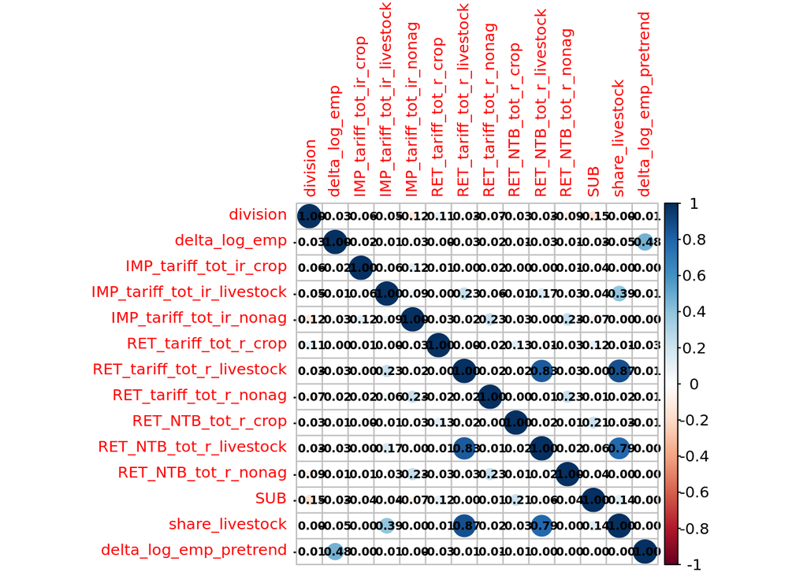

```
## NOTES: 2 observation removed because of 0-weight.
##        2,114 observations removed because of NA values (LHS: 1,396, RHS: 1,886).
## NOTES: 2 observation removed because of 0-weight.
##        2,114 observations removed because of NA values (LHS: 1,396, RHS: 1,886).
## NOTES: 2 observation removed because of 0-weight.
##        2,114 observations removed because of NA values (LHS: 1,396, RHS: 1,886).
```

```
## NOTES: 2 observation removed because of 0-weight.
##        2,128 observations removed because of NA values (LHS: 1,396, RHS: 2,076).
```

```
## NOTES: 2 observation removed because of 0-weight.
##        2,114 observations removed because of NA values (LHS: 1,396, RHS: 1,886).
## NOTES: 2 observation removed because of 0-weight.
##        2,114 observations removed because of NA values (LHS: 1,396, RHS: 1,886).
## NOTES: 2 observation removed because of 0-weight.
##        2,114 observations removed because of NA values (LHS: 1,396, RHS: 1,886).
```

```
## NOTES: 2 observation removed because of 0-weight.
##        2,128 observations removed because of NA values (LHS: 1,396, RHS: 2,076).
```

models[[1]]

models[[2]]

models[[3]]

models[[4]]

Dependent Var.:

delta_log_emp

delta_log_emp

delta_log_emp

delta_log_emp

IMP_tariff_tot_ir_crop

-0.1601* (0.0660)

-0.1580* (0.0652)

-0.1358. (0.0737)

-0.1519. (0.0858)

IMP_tariff_tot_ir_livestock

0.0175 (0.2432)

0.1825 (0.2683)

0.1666 (0.2919)

0.2004 (0.2931)

IMP_tariff_tot_ir_nonag

-0.0384 (0.1092)

-0.0368 (0.1089)

-0.0051 (0.1009)

-0.0249 (0.1122)

RET_tariff_tot_r_crop

0.1378 (0.1253)

0.1450 (0.1248)

0.1223 (0.1431)

-0.0489 (0.1992)

RET_tariff_tot_r_livestock

-0.5850 (0.3729)

-0.0197 (0.5134)

-0.1211 (0.7391)

-0.6456 (0.7878)

RET_tariff_tot_r_nonag

0.5575* (0.2411)

0.5566* (0.2411)

0.5890* (0.2474)

0.3533 (0.2176)

RET_NTB_tot_r_crop

0.1147 (0.1372)

0.1185 (0.1370)

0.1447 (0.1373)

0.1908 (0.1359)

RET_NTB_tot_r_livestock

0.5643 (1.147)

1.026 (1.147)

1.144 (1.204)

0.7861 (1.340)

RET_NTB_tot_r_nonag

0.2312 (0.3464)

0.2297 (0.3469)

0.2712 (0.3564)

0.4038 (0.4038)

SUB

-7.48e-5* (2.96e-5)

-6.11e-5* (2.97e-5)

-1.8e-5 (8.12e-5)

1.54e-7 (7.84e-5)

as.factor(year)2018 x share_livestock

-0.6893 (0.4986)

-0.5478 (0.8091)

-0.1318 (0.8241)

as.factor(year)2019 x share_livestock

-0.9385 (0.6011)

-0.6559 (0.9450)

-0.1942 (0.9691)

year x delta_log_emp_pretrend

0.0003* (0.0001)

Fixed-Effects:

——————-

——————-

—————–

—————–

Year FE

Yes

Yes

Yes

Yes

Sector x year-month FE

No

Yes

Yes

Yes

Census division x year-month FE

No

No

Yes

Yes

Pre-trend CZ outcome 2017

No

No

No

Yes

year

Yes

Yes

Yes

Yes

_____________________________________

___________________

___________________

_________________

_________________

S.E.: Clustered

by: fips

by: fips

by: fips

by: fips

Observations

4,166

4,166

4,166

4,152

R2

0.00127

0.00138

0.00549

0.28850

Adj. R2

-0.00137

-0.00174

-0.00148

0.28332

F-test

0.24248

0.22288

0.39772

28.154

F-test, p-value

0.99440

0.99826

0.99837

7.06e-131

RMSE

0.56930

0.56927

0.56810

0.48044

models[[1]]

models[[2]]

models[[3]]

models[[4]]

Dependent Var.:

delta_log_emp

delta_log_emp

delta_log_emp

delta_log_emp

IMP_tariff_tot_ir_crop

-0.1789** (0.0653)

-0.1784** (0.0651)

-0.1539* (0.0705)

-0.1598. (0.0829)

IMP_tariff_tot_ir_livestock

0.0521 (0.2409)

0.1154 (0.2713)

0.1066 (0.3062)

0.1436 (0.3080)

IMP_tariff_tot_ir_nonag

-0.0547 (0.1134)

-0.0553 (0.1136)

-0.0250 (0.1068)

-0.0388 (0.1165)

RET_tariff_tot_r_crop

0.0854 (0.1134)

0.0871 (0.1132)

0.0573 (0.1300)

-0.0556 (0.1686)

RET_tariff_tot_r_livestock

-0.1484 (0.2392)

0.1302 (0.4327)

0.0691 (0.6373)

-0.5185 (0.6984)

RET_tariff_tot_r_nonag

0.4374* (0.1930)

0.4379* (0.1929)

0.4809* (0.1894)

0.2663 (0.2235)

RET_NTB_tot_IV_r_crop

0.3924 (0.2752)

0.3975 (0.2749)

0.4797. (0.2792)

0.2491 (0.3185)

RET_NTB_tot_IV_r_livestock

-0.7010 (0.5685)

-0.4155 (0.7912)

-0.2786 (0.9216)

-0.2851 (0.9905)

RET_NTB_tot_IV_r_nonag

0.3359 (0.3943)

0.3357 (0.3946)

0.3628 (0.4018)

0.4209 (0.4320)

SUB

-7.03e-5* (2.86e-5)

-6.42e-5* (2.93e-5)

-2.33e-5 (8.21e-5)

6.22e-6 (8.02e-5)

as.factor(year)2018 x share_livestock

-0.4174 (0.5495)

-0.3349 (0.7063)

0.0486 (0.7879)

as.factor(year)2019 x share_livestock

-0.4774 (0.7880)

-0.2980 (0.9191)

0.1495 (1.056)

year x delta_log_emp_pretrend

0.0003* (0.0001)

Fixed-Effects:

——————-

——————-

——————

—————–

Year FE

Yes

Yes

Yes

Yes

Sector x year-month FE

No

Yes

Yes

Yes

Census division x year-month FE

No

No

Yes

Yes

Pre-trend CZ outcome 2017

No

No

No

Yes

year

Yes

Yes

Yes

Yes

_____________________________________

___________________

___________________

__________________

_________________

S.E.: Clustered

by: fips

by: fips

by: fips

by: fips

Observations

4,166

4,166

4,166

4,152

R2

0.00181

0.00183

0.00594

0.28861

Adj. R2

-0.00083

-0.00129

-0.00103

0.28343

F-test

0.34466

0.29485

0.43085

28.169

F-test, p-value

0.97551

0.99278

0.99664

6e-131

RMSE

0.56915

0.56914

0.56797

0.48040

## non ag

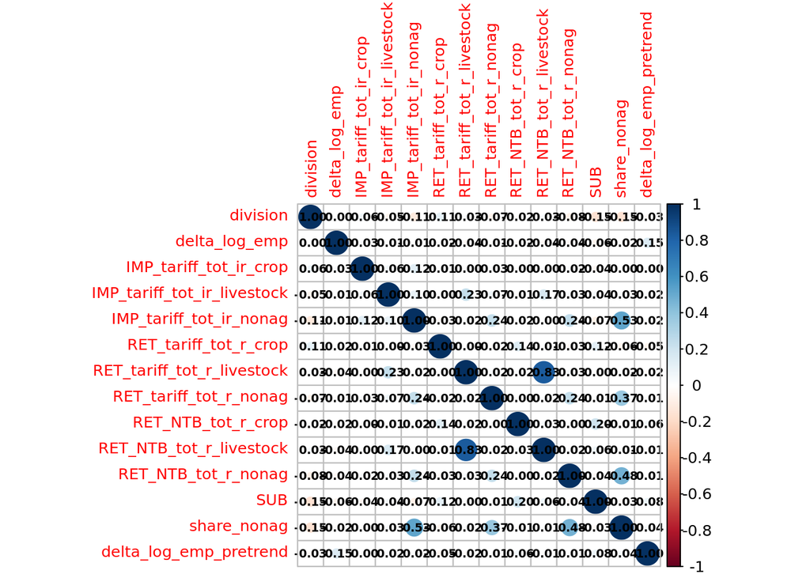

```
## NOTES: 2 observation removed because of 0-weight.
##        1,930 observations removed because of NA values (LHS: 295, RHS: 1,886).
## NOTES: 2 observation removed because of 0-weight.
##        1,930 observations removed because of NA values (LHS: 295, RHS: 1,886).
## NOTES: 2 observation removed because of 0-weight.
##        1,930 observations removed because of NA values (LHS: 295, RHS: 1,886).
```

```
## NOTES: 2 observation removed because of 0-weight.
##        1,930 observations removed because of NA values (LHS: 295, RHS: 1,922).
```

```
## NOTES: 2 observation removed because of 0-weight.
##        1,930 observations removed because of NA values (LHS: 295, RHS: 1,886).
## NOTES: 2 observation removed because of 0-weight.
##        1,930 observations removed because of NA values (LHS: 295, RHS: 1,886).
## NOTES: 2 observation removed because of 0-weight.
##        1,930 observations removed because of NA values (LHS: 295, RHS: 1,886).
```

```
## NOTES: 2 observation removed because of 0-weight.
##        1,930 observations removed because of NA values (LHS: 295, RHS: 1,922).
```

models[[1]]

models[[2]]

models[[3]]

models[[4]]

Dependent Var.:

delta_log_emp

delta_log_emp

delta_log_emp

delta_log_emp

IMP_tariff_tot_ir_crop

-0.0410** (0.0151)

-0.0436** (0.0158)

-0.0375. (0.0201)

-0.0415. (0.0216)

IMP_tariff_tot_ir_livestock

-0.0626 (0.0886)

-0.0607 (0.0882)

-0.0738 (0.0932)

-0.0902 (0.0926)

IMP_tariff_tot_ir_nonag

-0.0678** (0.0259)

-0.0421 (0.0258)

-0.0350 (0.0249)

-0.0350 (0.0261)

RET_tariff_tot_r_crop

-0.0050 (0.0913)

-0.0057 (0.0915)

-0.0173 (0.0919)

-0.0224 (0.0941)

RET_tariff_tot_r_livestock

-0.2161 (0.1777)

-0.2197 (0.1777)

-0.1853 (0.1804)

-0.1662 (0.1816)

RET_tariff_tot_r_nonag

-0.0331 (0.0577)

0.0203 (0.0767)

0.0454 (0.0766)

0.0788 (0.0835)

RET_NTB_tot_r_crop

-0.0682 (0.0643)

-0.0667 (0.0646)

-0.0568 (0.0662)

-0.0614 (0.0630)

RET_NTB_tot_r_livestock

0.3709 (0.5323)

0.3924 (0.5327)

0.2911 (0.5389)

0.3248 (0.5392)

RET_NTB_tot_r_nonag

-0.0743 (0.0826)

-0.0423 (0.0823)

-0.0465 (0.0802)

-0.0319 (0.0845)

SUB

-1.15e-5 (1.38e-5)

-1.08e-5 (1.39e-5)

-1.16e-5 (1.43e-5)

-1.54e-5 (1.47e-5)

as.factor(year)2018 x share_nonag

-0.0285 (0.0816)

-0.0113 (0.0748)

-0.0431 (0.0791)

as.factor(year)2019 x share_nonag

-0.1337 (0.1197)

-0.1107 (0.1213)

-0.1459 (0.1263)

year x delta_log_emp_pretrend

6.19e-5 (5.22e-5)

Fixed-Effects:

——————

——————

——————

——————

Year FE

Yes

Yes

Yes

Yes

Sector x year-month FE

No

Yes

Yes

Yes

Census division x year-month FE

No

No

Yes

Yes

Pre-trend CZ outcome 2017

No

No

No

Yes

year

Yes

Yes

Yes

Yes

_________________________________

__________________

__________________

__________________

__________________

S.E.: Clustered

by: fips

by: fips

by: fips

by: fips

Observations

4,350

4,350

4,350

4,350

R2

0.01642

0.01702

0.02821

0.04182

Adj. R2

0.01393

0.01407

0.02168

0.03516

F-test

3.3025

2.8977

2.1780

3.1655

F-test, p-value

0.00016

0.00035

0.00029

1.89e-8

RMSE

0.11612

0.11609

0.11542

0.11461

models[[1]]

models[[2]]

models[[3]]

models[[4]]

Dependent Var.:

delta_log_emp

delta_log_emp

delta_log_emp

delta_log_emp

IMP_tariff_tot_ir_crop

-0.0346* (0.0161)

-0.0383* (0.0164)

-0.0321 (0.0207)

-0.0355 (0.0222)

IMP_tariff_tot_ir_livestock

-0.0436 (0.0890)

-0.0427 (0.0887)

-0.0519 (0.0934)

-0.0684 (0.0927)

IMP_tariff_tot_ir_nonag

-0.0703** (0.0266)

-0.0359 (0.0257)

-0.0294 (0.0247)

-0.0299 (0.0259)

RET_tariff_tot_r_crop

0.0088 (0.0926)

0.0084 (0.0927)

-0.0045 (0.0932)

-0.0075 (0.0943)

RET_tariff_tot_r_livestock

-0.0103 (0.1609)

-0.0138 (0.1608)

0.0200 (0.1667)

0.0503 (0.1662)

RET_tariff_tot_r_nonag

-0.0576 (0.0395)

0.0072 (0.0701)

0.0337 (0.0665)

0.0671 (0.0764)

RET_NTB_tot_IV_r_crop

-0.1127 (0.1107)

-0.1115 (0.1109)

-0.0916 (0.1130)

-0.1054 (0.1091)

RET_NTB_tot_IV_r_livestock

-0.2617 (0.3492)

-0.2323 (0.3506)

-0.3149 (0.3559)

-0.3170 (0.3551)

RET_NTB_tot_IV_r_nonag

-0.0231 (0.0996)

0.0350 (0.1002)

0.0278 (0.1038)

0.0347 (0.1097)

SUB

-8.8e-6 (1.34e-5)

-7.22e-6 (1.36e-5)

-8.47e-6 (1.42e-5)

-1.2e-5 (1.45e-5)

as.factor(year)2018 x share_nonag

-0.0617 (0.0796)

-0.0432 (0.0725)

-0.0704 (0.0763)

as.factor(year)2019 x share_nonag

-0.1886 (0.1314)

-0.1603 (0.1279)

-0.1928 (0.1323)

year x delta_log_emp_pretrend

6.22e-5 (5.21e-5)

Fixed-Effects:

——————

——————

——————

—————–

Year FE

Yes

Yes

Yes

Yes

Sector x year-month FE

No

Yes

Yes

Yes

Census division x year-month FE

No

No

Yes

Yes

Pre-trend CZ outcome 2017

No

No

No

Yes

year

Yes

Yes

Yes

Yes

_________________________________

__________________

__________________

__________________

_________________

S.E.: Clustered

by: fips

by: fips

by: fips

by: fips

Observations

4,350

4,350

4,350

4,350

R2

0.01600

0.01703

0.02838

0.04213

Adj. R2

0.01350

0.01409

0.02186

0.03548

F-test

3.2158

2.9007

2.1916

3.1904

F-test, p-value

0.00023

0.00035

0.00026

1.46e-8

RMSE

0.11615

0.11609

0.11541

0.11459

# Log wage change

## Crop sector

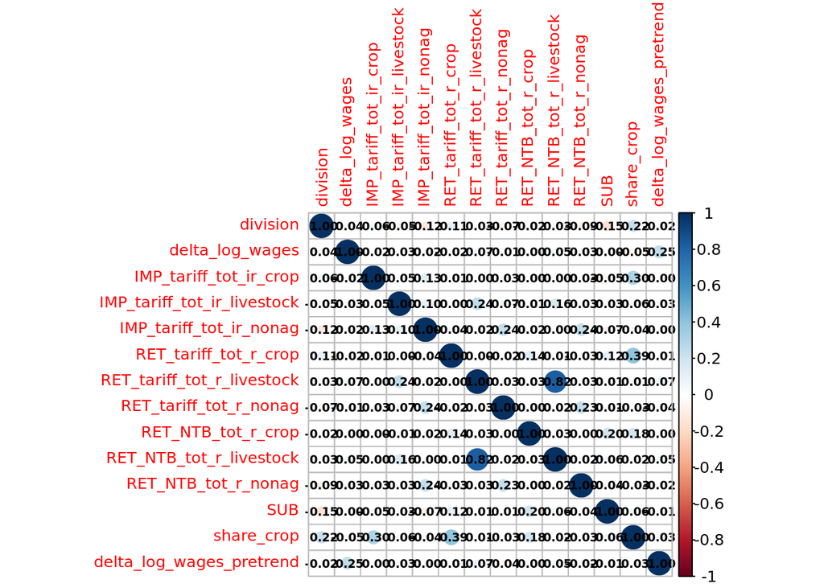

```
## NOTES: 2 observation removed because of 0-weight.
##        1,959 observations removed because of NA values (LHS: 618, RHS: 1,886).
## NOTES: 2 observation removed because of 0-weight.
##        1,959 observations removed because of NA values (LHS: 618, RHS: 1,886).
## NOTES: 2 observation removed because of 0-weight.
##        1,959 observations removed because of NA values (LHS: 618, RHS: 1,886).
```

```
## NOTES: 2 observation removed because of 0-weight.
##        1,966 observations removed because of NA values (LHS: 618, RHS: 1,950).
```

```
## NOTES: 2 observation removed because of 0-weight.
##        1,959 observations removed because of NA values (LHS: 618, RHS: 1,886).
## NOTES: 2 observation removed because of 0-weight.
##        1,959 observations removed because of NA values (LHS: 618, RHS: 1,886).
## NOTES: 2 observation removed because of 0-weight.
##        1,959 observations removed because of NA values (LHS: 618, RHS: 1,886).
```

```
## NOTES: 2 observation removed because of 0-weight.
##        1,966 observations removed because of NA values (LHS: 618, RHS: 1,950).
```

models[[1]]

models[[2]]

models[[3]]

models[[4]]

Dependent Var.:

delta_log_wages

delta_log_wages

delta_log_wages

delta_log_wages

IMP_tariff_tot_ir_crop

-0.0397 (0.0612)

0.0818* (0.0376)

0.0745* (0.0348)

0.0812* (0.0350)

IMP_tariff_tot_ir_livestock

-0.0309 (0.2641)

0.0353 (0.2669)

0.1092 (0.3048)

0.0765 (0.3003)

IMP_tariff_tot_ir_nonag

0.0099 (0.0865)

0.0089 (0.0867)

0.0119 (0.0867)

0.0083 (0.0847)

RET_tariff_tot_r_crop

-0.1786. (0.0916)

0.0520 (0.0795)

-0.0410 (0.0843)

-0.0337 (0.0843)

RET_tariff_tot_r_livestock

1.036* (0.5267)

1.016. (0.5250)

0.9571. (0.5392)

0.8156 (0.5168)

RET_tariff_tot_r_nonag

-0.4534 (0.3143)

-0.4597 (0.3135)

-0.3929 (0.3065)

-0.3980 (0.3073)

RET_NTB_tot_r_crop

-0.0007 (0.0734)

0.0323 (0.0714)

0.0272 (0.0760)

0.0136 (0.0754)

RET_NTB_tot_r_livestock

-0.6438 (1.273)

-0.5949 (1.270)

-0.7696 (1.342)

-0.5955 (1.363)

RET_NTB_tot_r_nonag

0.4071 (0.2638)

0.4063 (0.2630)

0.3522 (0.2623)

0.4480 (0.2859)

SUB

-7.07e-6 (2.65e-5)

-8.51e-6 (2.66e-5)

2.77e-5 (3e-5)

3.67e-5 (3.22e-5)

as.factor(year)2018 x share_crop

-0.5857*** (0.1725)

-0.5724*** (0.1713)

-0.6477*** (0.1766)

as.factor(year)2019 x share_crop

-0.9611*** (0.2670)

-1.091*** (0.2595)

-1.169*** (0.2632)

year x delta_log_wages_pretrend

7.67e-5*** (1.85e-5)

Fixed-Effects:

——————

——————-

——————-

——————–

Year FE

Yes

Yes

Yes

Yes

Sector x year-month FE

No

Yes

Yes

Yes

Census division x year-month FE

No

No

Yes

Yes

Pre-trend CZ outcome 2017

No

No

No

Yes

year

Yes

Yes

Yes

Yes

________________________________

__________________

___________________

___________________

____________________

S.E.: Clustered

by: fips

by: fips

by: fips

by: fips

Observations

4,321

4,321

4,321

4,314

R2

0.00743

0.00907

0.01921

0.04174

Adj. R2

0.00490

0.00608

0.01258

0.03503

F-test

1.4718

1.5217

1.4602

3.1337

F-test, p-value

0.13519

0.10183

0.05390

2.62e-8

RMSE

0.32464

0.32437

0.32271

0.31898

models[[1]]

models[[2]]

models[[3]]

models[[4]]

Dependent Var.:

delta_log_wages

delta_log_wages

delta_log_wages

delta_log_wages

IMP_tariff_tot_ir_crop

-0.0301 (0.0570)

0.0811* (0.0376)

0.0729* (0.0352)

0.0790* (0.0353)

IMP_tariff_tot_ir_livestock

-0.0413 (0.2771)

0.0198 (0.2791)

0.0812 (0.3155)

0.0389 (0.3110)

IMP_tariff_tot_ir_nonag

0.0263 (0.0831)

0.0241 (0.0832)

0.0272 (0.0853)

0.0276 (0.0839)

RET_tariff_tot_r_crop

-0.1438. (0.0840)

0.0416 (0.0775)

-0.0495 (0.0830)

-0.0419 (0.0832)

RET_tariff_tot_r_livestock

0.8213. (0.4956)

0.7880 (0.4929)

0.5883 (0.5109)

0.4576 (0.4805)

RET_tariff_tot_r_nonag

-0.3225 (0.2295)

-0.3229 (0.2264)

-0.2625 (0.2233)

-0.2313 (0.2001)

RET_NTB_tot_IV_r_crop

-0.1802 (0.1466)

0.0602 (0.1422)

0.0431 (0.1481)

0.0029 (0.1481)

RET_NTB_tot_IV_r_livestock

0.1142 (0.7510)

0.1554 (0.7501)

0.4046 (0.7262)

0.5245 (0.7349)

RET_NTB_tot_IV_r_nonag

0.1228 (0.1946)

0.1195 (0.1943)

0.0747 (0.1760)

0.0933 (0.1867)

SUB

-1.72e-6 (2.49e-5)

-9.63e-6 (2.52e-5)

2.49e-5 (2.96e-5)

3.44e-5 (3.16e-5)

as.factor(year)2018 x share_crop

-0.6146*** (0.1815)

-0.6091*** (0.1806)

-0.6779*** (0.1832)

as.factor(year)2019 x share_crop

-0.9742*** (0.2824)

-1.126*** (0.2749)

-1.190*** (0.2762)

year x delta_log_wages_pretrend

7.5e-5*** (1.91e-5)

Fixed-Effects:

——————

——————-

——————-

——————-

Year FE

Yes

Yes

Yes

Yes

Sector x year-month FE

No

Yes

Yes

Yes

Census division x year-month FE

No

No

Yes

Yes

Pre-trend CZ outcome 2017

No

No

No

Yes

year

Yes

Yes

Yes

Yes

________________________________

__________________

___________________

___________________

___________________

S.E.: Clustered

by: fips

by: fips

by: fips

by: fips

Observations

4,321

4,321

4,321

4,314

R2

0.00550

0.00702

0.01769

0.03936

Adj. R2

0.00296

0.00402

0.01105

0.03263

F-test

1.0876

1.1758

1.3422

2.9472

F-test, p-value

0.36701

0.29079

0.10518

1.73e-7

RMSE

0.32495

0.32470

0.32296

0.31937

## Livestock sector

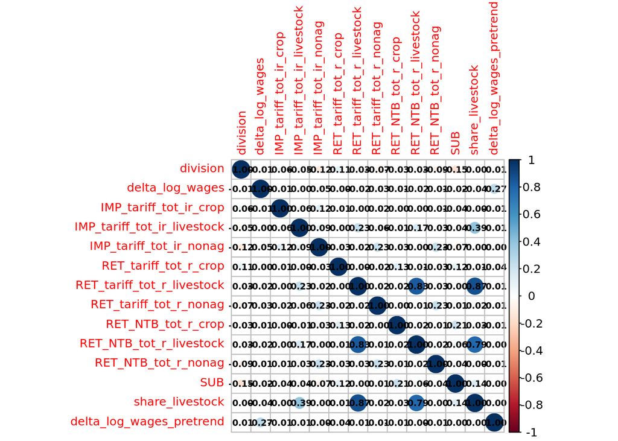

```
## NOTES: 2 observation removed because of 0-weight.
##        2,114 observations removed because of NA values (LHS: 1,395, RHS: 1,886).
## NOTES: 2 observation removed because of 0-weight.
##        2,114 observations removed because of NA values (LHS: 1,395, RHS: 1,886).
## NOTES: 2 observation removed because of 0-weight.
##        2,114 observations removed because of NA values (LHS: 1,395, RHS: 1,886).
```

```
## NOTES: 2 observation removed because of 0-weight.
##        2,128 observations removed because of NA values (LHS: 1,395, RHS: 2,076).
```

```
## NOTES: 2 observation removed because of 0-weight.
##        2,114 observations removed because of NA values (LHS: 1,395, RHS: 1,886).
## NOTES: 2 observation removed because of 0-weight.
##        2,114 observations removed because of NA values (LHS: 1,395, RHS: 1,886).
## NOTES: 2 observation removed because of 0-weight.
##        2,114 observations removed because of NA values (LHS: 1,395, RHS: 1,886).
```

```
## NOTES: 2 observation removed because of 0-weight.
##        2,128 observations removed because of NA values (LHS: 1,395, RHS: 2,076).
```

models[[1]]

models[[2]]

models[[3]]

models[[4]]

Dependent Var.:

delta_log_wages

delta_log_wages

delta_log_wages

delta_log_wages

IMP_tariff_tot_ir_crop

-0.0544 (0.0826)

-0.0535 (0.0818)

-0.0131 (0.1028)

-0.0004 (0.1111)

IMP_tariff_tot_ir_livestock

0.1313 (0.3087)

0.1977 (0.3389)

0.2005 (0.3695)

0.1822 (0.3702)

IMP_tariff_tot_ir_nonag

0.0702 (0.1048)

0.0710 (0.1045)

0.0866 (0.1068)

0.0903 (0.1039)

RET_tariff_tot_r_crop

0.3861. (0.2023)

0.3888. (0.2021)

0.3354 (0.2264)

0.2286 (0.1761)

RET_tariff_tot_r_livestock

-0.4526 (0.4776)

-0.2513 (0.6152)

-0.5260 (0.9669)

-0.8026 (0.9719)

RET_tariff_tot_r_nonag

0.5846* (0.2657)

0.5838* (0.2658)

0.6177* (0.2637)

0.4904. (0.2589)

RET_NTB_tot_r_crop

0.1858 (0.1540)

0.1882 (0.1540)

0.2052 (0.1536)

0.2394. (0.1445)

RET_NTB_tot_r_livestock

0.9191 (1.436)

1.090 (1.466)

1.144 (1.552)

0.9618 (1.580)

RET_NTB_tot_r_nonag

0.2004 (0.3982)

0.2000 (0.3987)

0.2247 (0.4021)

0.3721 (0.4297)

SUB

-6.89e-5. (3.61e-5)

-6.46e-5. (3.67e-5)

-2e-5 (0.0001)

-1.25e-5 (0.0001)

as.factor(year)2018 x share_livestock

-0.2162 (0.5722)

-0.0185 (1.068)

0.2417 (1.073)

as.factor(year)2019 x share_livestock

-0.3714 (0.6976)

0.0172 (1.223)

0.2968 (1.232)

year x delta_log_wages_pretrend

0.0001*** (2.57e-5)

Fixed-Effects:

——————-

——————-

—————-

——————-

Year FE

Yes

Yes

Yes

Yes

Sector x year-month FE

No

Yes

Yes

Yes

Census division x year-month FE

No

No

Yes

Yes

Pre-trend CZ outcome 2017

No

No

No

Yes

year

Yes

Yes

Yes

Yes

_____________________________________

___________________

___________________

________________

___________________

S.E.: Clustered

by: fips

by: fips

by: fips

by: fips

Observations

4,166

4,166

4,166

4,152

R2

0.00236

0.00238

0.00778

0.07354

Adj. R2

-0.00029

-0.00075

0.00082

0.06680

F-test

0.44865

0.38313

0.56503

5.5115

F-test, p-value

0.93404

0.97546

0.97035

1.02e-19

RMSE

0.50871

0.50870

0.50733

0.48992

models[[1]]

models[[2]]

models[[3]]

models[[4]]

Dependent Var.:

delta_log_wages

delta_log_wages

delta_log_wages

delta_log_wages

IMP_tariff_tot_ir_crop

-0.0875 (0.0860)

-0.0877 (0.0860)

-0.0423 (0.0992)

-0.0228 (0.1081)

IMP_tariff_tot_ir_livestock

0.1393 (0.3053)

0.1199 (0.3476)

0.1352 (0.3891)

0.1235 (0.3914)

IMP_tariff_tot_ir_nonag

0.0508 (0.1074)

0.0508 (0.1076)

0.0629 (0.1104)

0.0678 (0.1099)

RET_tariff_tot_r_crop

0.2870. (0.1624)

0.2866. (0.1621)

0.2298 (0.1844)

0.1616 (0.1554)

RET_tariff_tot_r_livestock

-0.0362 (0.2995)

-0.1010 (0.5307)

-0.3426 (0.8458)

-0.6345 (0.8622)

RET_tariff_tot_r_nonag

0.4600* (0.2115)

0.4599* (0.2116)

0.4894* (0.2050)

0.3604. (0.2182)

RET_NTB_tot_IV_r_crop

0.6620. (0.3639)

0.6601. (0.3637)

0.7287. (0.3781)

0.5881. (0.3087)

RET_NTB_tot_IV_r_livestock

-0.3925 (0.6743)

-0.4842 (1.004)

-0.3270 (1.183)

-0.2576 (1.209)

RET_NTB_tot_IV_r_nonag

0.3247 (0.4357)

0.3249 (0.4359)

0.3624 (0.4312)

0.4668 (0.4912)

SUB

-7.06e-5* (3.57e-5)

-7.17e-5. (3.67e-5)

-3.02e-5 (0.0001)

-1.49e-5 (0.0001)

as.factor(year)2018 x share_livestock

0.0883 (0.6943)

0.2083 (0.9664)

0.4137 (0.9984)

as.factor(year)2019 x share_livestock

0.1440 (1.021)

0.3993 (1.243)

0.6163 (1.301)

year x delta_log_wages_pretrend

0.0001*** (2.57e-5)

Fixed-Effects:

——————-

——————-

—————–

——————-

Year FE

Yes

Yes

Yes

Yes

Sector x year-month FE

No

Yes

Yes

Yes

Census division x year-month FE

No

No

Yes

Yes

Pre-trend CZ outcome 2017

No

No

No

Yes

year

Yes

Yes

Yes

Yes

_____________________________________

___________________

___________________

_________________

___________________

S.E.: Clustered

by: fips

by: fips

by: fips

by: fips

Observations

4,166

4,166

4,166

4,152

R2

0.00323

0.00323

0.00876

0.07432

Adj. R2

0.00059

0.00011

0.00181

0.06758

F-test

0.61581

0.52133

0.63708

5.5742

F-test, p-value

0.81681

0.91293

0.93315

4.96e-20

RMSE

0.50849

0.50849

0.50707

0.48971

## non ag

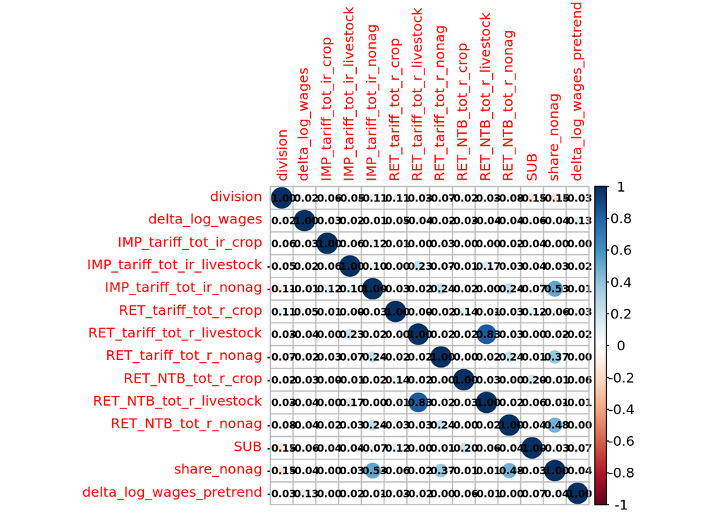

```
## NOTES: 2 observation removed because of 0-weight.
##        1,930 observations removed because of NA values (LHS: 295, RHS: 1,886).
## NOTES: 2 observation removed because of 0-weight.
##        1,930 observations removed because of NA values (LHS: 295, RHS: 1,886).
## NOTES: 2 observation removed because of 0-weight.
##        1,930 observations removed because of NA values (LHS: 295, RHS: 1,886).
```

```
## NOTES: 2 observation removed because of 0-weight.
##        1,930 observations removed because of NA values (LHS: 295, RHS: 1,922).
```

```
## NOTES: 2 observation removed because of 0-weight.
##        1,930 observations removed because of NA values (LHS: 295, RHS: 1,886).
## NOTES: 2 observation removed because of 0-weight.
##        1,930 observations removed because of NA values (LHS: 295, RHS: 1,886).
## NOTES: 2 observation removed because of 0-weight.
##        1,930 observations removed because of NA values (LHS: 295, RHS: 1,886).
```

```
## NOTES: 2 observation removed because of 0-weight.
##        1,930 observations removed because of NA values (LHS: 295, RHS: 1,922).
```

models[[1]]

models[[2]]

models[[3]]

models[[4]]

Dependent Var.:

delta_log_wages

delta_log_wages

delta_log_wages

delta_log_wages

IMP_tariff_tot_ir_crop

-0.0168 (0.0573)

-0.0222 (0.0575)

-0.0214 (0.0620)

-0.0244 (0.0628)

IMP_tariff_tot_ir_livestock

-0.0751 (0.1129)

-0.0711 (0.1123)

-0.0770 (0.1181)

-0.0850 (0.1158)

IMP_tariff_tot_ir_nonag

-0.1180** (0.0418)

-0.0638 (0.0441)

-0.0495 (0.0418)

-0.0492 (0.0431)

RET_tariff_tot_r_crop

0.0371 (0.1119)

0.0352 (0.1124)

0.0101 (0.1132)

0.0046 (0.1144)

RET_tariff_tot_r_livestock

-0.1838 (0.1938)

-0.1907 (0.1938)

-0.1088 (0.1964)

-0.0912 (0.1976)

RET_tariff_tot_r_nonag

-0.1639. (0.0853)

-0.0471 (0.1227)

-0.0243 (0.1122)

0.0039 (0.1160)

RET_NTB_tot_r_crop

-0.0824 (0.0714)

-0.0793 (0.0718)

-0.0578 (0.0751)

-0.0612 (0.0726)

RET_NTB_tot_r_livestock

0.1347 (0.5801)

0.1818 (0.5788)

0.0799 (0.5807)

0.0877 (0.5822)

RET_NTB_tot_r_nonag

-0.1728 (0.1173)

-0.0993 (0.1146)

-0.1120 (0.1095)

-0.1024 (0.1146)

SUB

-1.57e-5 (1.43e-5)

-1.38e-5 (1.47e-5)

-4.26e-6 (1.52e-5)

-7.12e-6 (1.59e-5)

as.factor(year)2018 x share_nonag

-0.0827 (0.1459)

-0.0350 (0.1261)

-0.0538 (0.1268)

as.factor(year)2019 x share_nonag

-0.2801 (0.2133)

-0.2253 (0.2003)

-0.2475 (0.2029)

year x delta_log_wages_pretrend

3.75e-5 (4.91e-5)

Fixed-Effects:

——————

——————

——————

——————

Year FE

Yes

Yes

Yes

Yes

Sector x year-month FE

No

Yes

Yes

Yes

Census division x year-month FE

No

No

Yes

Yes

Pre-trend CZ outcome 2017

No

No

No

Yes

year

Yes

Yes

Yes

Yes

_________________________________

__________________

__________________

__________________

__________________

S.E.: Clustered

by: fips

by: fips

by: fips

by: fips

Observations

4,350

4,350

4,350

4,350

R2

0.03891

0.04057

0.05452

0.05918

Adj. R2

0.03648

0.03769

0.04817

0.05265

F-test

8.0095

7.0772

4.3265

4.5627

F-test, p-value

7.9e-14

1.2e-13

1.69e-13

4.97e-15

RMSE

0.14388

0.14376

0.14271

0.14236

models[[1]]

models[[2]]

models[[3]]

models[[4]]

Dependent Var.:

delta_log_wages

delta_log_wages

delta_log_wages

delta_log_wages

IMP_tariff_tot_ir_crop

-0.0088 (0.0593)

-0.0149 (0.0587)

-0.0153 (0.0631)

-0.0178 (0.0639)

IMP_tariff_tot_ir_livestock

-0.0501 (0.1145)

-0.0486 (0.1141)

-0.0543 (0.1199)

-0.0629 (0.1175)

IMP_tariff_tot_ir_nonag

-0.1170** (0.0428)

-0.0586 (0.0444)

-0.0459 (0.0416)

-0.0452 (0.0428)

RET_tariff_tot_r_crop

0.0545 (0.1128)

0.0535 (0.1131)

0.0264 (0.1139)

0.0225 (0.1143)

RET_tariff_tot_r_livestock

-0.0277 (0.1725)

-0.0320 (0.1719)

0.0351 (0.1800)

0.0501 (0.1792)

RET_tariff_tot_r_nonag

-0.1690** (0.0555)

-0.0540 (0.1124)

-0.0257 (0.0993)

0.0010 (0.1021)

RET_NTB_tot_IV_r_crop

-0.1475 (0.1268)

-0.1455 (0.1271)

-0.1163 (0.1291)

-0.1258 (0.1262)

RET_NTB_tot_IV_r_livestock

-0.3235 (0.3525)

-0.2747 (0.3546)

-0.3171 (0.3595)

-0.3025 (0.3588)

RET_NTB_tot_IV_r_nonag

-0.1229 (0.1606)

-0.0224 (0.1611)

-0.0541 (0.1638)

-0.0416 (0.1724)

SUB

-1.34e-5 (1.39e-5)

-1.02e-5 (1.43e-5)

-1.01e-6 (1.5e-5)

-3.85e-6 (1.57e-5)

as.factor(year)2018 x share_nonag

-0.1240 (0.1426)

-0.0701 (0.1239)

-0.0888 (0.1245)

as.factor(year)2019 x share_nonag

-0.3181 (0.2301)

-0.2429 (0.2147)

-0.2709 (0.2189)

year x delta_log_wages_pretrend

3.77e-5 (4.92e-5)

Fixed-Effects:

——————

——————

—————–

——————

Year FE

Yes

Yes

Yes

Yes

Sector x year-month FE

No

Yes

Yes

Yes

Census division x year-month FE

No

No

Yes

Yes

Pre-trend CZ outcome 2017

No

No

No

Yes

year

Yes

Yes

Yes

Yes

_________________________________

__________________

__________________

_________________

__________________

S.E.: Clustered

by: fips

by: fips

by: fips

by: fips

Observations

4,350

4,350

4,350

4,350

R2

0.03833

0.04029

0.05434

0.05904

Adj. R2

0.03590

0.03741

0.04799

0.05250

F-test

7.8853

7.0264

4.3115

4.5509

F-test, p-value

1.43e-13

1.59e-13

1.99e-13

5.68e-15

RMSE

0.14393

0.14378

0.14272

0.14237